# Mini-Project 02 - How Do You Do ‘You Do You’?

#### T6-Q5: Childcare time per child — middle-child syndrome

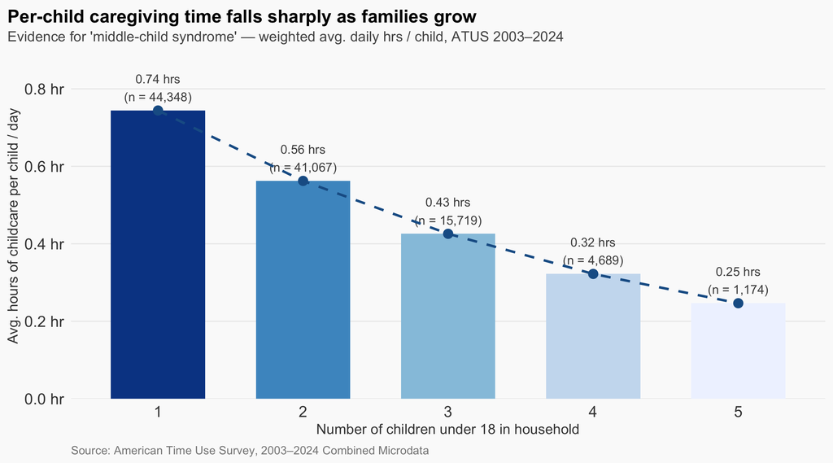

```r
care_per_person <- atus_act |>
  filter(level3_code %in% childcare_codes) |>
  group_by(participant_id) |>
  summarise(care_min = sum(time_spent_min, na.rm = TRUE), .groups = "drop")

per_child_summary <- raw_resp |>
  select(participant_id = TUCASEID, n_children = TRCHILDNUM,
         survey_weight = TUFNWGTP) |>
  filter(n_children >= 1L, n_children <= 5L) |>
  left_join(care_per_person, by = "participant_id") |>
  mutate(
    care_min           = replace_na(care_min, 0),
    care_per_child_min = care_min / n_children
  ) |>
  group_by(n_children) |>
  summarise(
    n_parents         = n(),
    avg_per_child_hrs = weighted.mean(care_per_child_min / 60,
                                      survey_weight, na.rm = TRUE),
    .groups = "drop"
  )

ggplot(per_child_summary,
       aes(x = factor(n_children), y = avg_per_child_hrs)) +
  geom_col(aes(fill = avg_per_child_hrs), width = 0.65, show.legend = FALSE) +
  geom_text(
    aes(label = sprintf("%.2f hrs\n(n = %s)", avg_per_child_hrs, comma(n_parents))),
    vjust = -0.35, size = 3.4, color = "grey30"
  ) +
  geom_line(aes(group = 1), color = pal_blue, linewidth = 0.9, linetype = "dashed") +
  geom_point(color = pal_blue, size = 3) +
  scale_fill_distiller(palette = "Blues", direction = 1) +
  scale_y_continuous(expand = expansion(mult = c(0, 0.2)),
                     labels = label_number(suffix = " hr")) +
  theme_atus() +
  labs(
    title    = "Per-child caregiving time falls sharply as families grow",
    subtitle = "Evidence for 'middle-child syndrome' — weighted avg. daily hrs / child, ATUS 2003–2024",
    x        = "Number of children under 18 in household",
    y        = "Avg. hours of childcare per child / day",
    caption  = "Source: American Time Use Survey, 2003–2024 Combined Microdata"
  )
```

The pattern is unmistakable: each additional child dilutes per-child caregiving time dramatically. Parents of a single child invest roughly twice as many caregiving hours per child as parents of three or more. The dashed trend line makes the decline visceral — this is a steep curve, not a gentle taper. Two caveats are worth noting. First, some of this decline reflects efficiency gains: reading a bedtime story to three children simultaneously takes the same 20 minutes as reading to one. Second, the diary-day measure under-counts ambient attention — keeping an eye on a toddler while cooking, for instance — which may scale more linearly with child count. Even with these caveats, the data gives quantitative weight to what many middle children have long felt.

## Final Insights and Deliverable

Your company is launching a time-tracking app that helps users compare their daily habits against demographically similar peers and uses gamification to encourage healthier routines. The graphics team needs “typical user” time-use profiles for three representative demographics to inform UI design. Below, I define each demographic, identify the key activities most worth tracking, estimate typical and target time levels, and calculate what fraction of real ATUS respondents currently hit those targets.

**Methodology.** For each demographic, I use a `left_join` from the respondent pool to their activity totals, zero-imputing non-participants. “Low”, “typical”, and “high” correspond to the 25th-percentile, weighted mean, and 75th-percentile of the distribution. Targets are informed by widely cited benchmarks: the CDC recommends ≥7 hours of sleep for adults, 150 minutes/week of moderate exercise (≈22 min/day), and so on.

```r
# Generic helper: given a respondent pool (df with participant_id + survey_weight)
# and a set of activity codes, return low/mean/high minutes and % meeting target.
time_use_profile <- function(resp_df, act_df, act_codes, target_min) {
  per_person <- act_df |>
    filter(level3_code %in% act_codes) |>
    group_by(participant_id) |>
    summarise(total_min = sum(time_spent_min, na.rm = TRUE), .groups = "drop")

  joined <- resp_df |>
    left_join(per_person, by = "participant_id") |>
    mutate(
      total_min = replace_na(total_min, 0),
      survey_weight = replace_na(survey_weight, 0)
    )

  if (nrow(joined) == 0) {
    return(tibble(
      n = 0,
      low_min = 0,
      mean_min = 0,
      high_min = 0,
      pct_target = 0
    ))
  }

  if (sum(joined$survey_weight, na.rm = TRUE) == 0) {
    return(tibble(
      n = nrow(joined),
      low_min = unname(quantile(joined$total_min, 0.25, na.rm = TRUE, type = 7)),
      mean_min = mean(joined$total_min, na.rm = TRUE),
      high_min = unname(quantile(joined$total_min, 0.75, na.rm = TRUE, type = 7)),
      pct_target = mean(joined$total_min >= target_min, na.rm = TRUE)
    ))
  }

  tibble(
    n = nrow(joined),
    low_min = unname(quantile(joined$total_min, 0.25, na.rm = TRUE, type = 7)),
    mean_min = weighted.mean(joined$total_min, joined$survey_weight, na.rm = TRUE),
    high_min = unname(quantile(joined$total_min, 0.75, na.rm = TRUE, type = 7)),
    pct_target = weighted.mean(as.numeric(joined$total_min >= target_min),
                               joined$survey_weight, na.rm = TRUE)
  ) |>
    mutate(
      low_min = replace_na(low_min, 0),
      mean_min = replace_na(mean_min, 0),
      high_min = replace_na(high_min, 0),
      pct_target = replace_na(pct_target, 0)
    )
}

# Nicely format a profile tibble into a publication-quality gt table
profile_gt <- function(results_tbl, demo_title, demo_subtitle) {
  results_tbl |>
    select(activity, low_min, mean_min, high_min, target_min, pct_target) |>
    gt() |>
    tab_header(title = demo_title, subtitle = demo_subtitle) |>
    cols_label(
      activity   = "Activity",
      low_min    = "Low (25th pct.)",
      mean_min   = "Typical (wtd. mean)",
      high_min   = "High (75th pct.)",
      target_min = "App target",
      pct_target = "% meeting target"
    ) |>
    tab_spanner("Daily minutes", columns = c(low_min, mean_min, high_min, target_min)) |>
    fmt_number(columns = c(low_min, mean_min, high_min, target_min), decimals = 0) |>
    fmt_percent(columns = pct_target, decimals = 1) |>
    gt_color_rows(
      columns = pct_target,
      palette = c("#d73027", "#ffffbf", "#1a9850"),
      domain  = c(0, 1)
    ) |>
    tab_footnote(
      paste0(
        "Targets: Sleep ≥ 420 min (CDC adult recommendation); ",
        "Exercise ≥ 22 min/day (150 min/wk CDC goal); ",
        "others reflect health-informed best practice."
      ),
      locations = cells_column_labels(columns = target_min)
    ) |>
    tab_source_note("Source: American Time Use Survey, 2003–2024 Combined Microdata") |>
    opt_stylize(style = 6)
}
```